# Live coding 7

Andrew Irwin

2021-02-25 8:35

# Agenda

- Questions arising from lessons, tasks
- Collaborating with GitHub, especially creating a team for your project
- Finding data to work with for your project
- Reproducible reports

The plan for the live coding is for us to work together to solve problems using tools from this week’s lessons. The skills from this week are about collaborating, finding data, and writing reports. These skills will all be essential for your term project.

Today I will work through examples

- using the `team-planning` repository to create a team (individual or two people),
- finding and working with data from TidyTuesday or other sources you ask me about,
- some tips on working with R markdown documents.

## Collaborating with GitHub

I will switch to a difference R project and show you how to add yourself to a team for the term project.

## Working with external data

We will go to the [TidyTuesday](https://github.com/rfordatascience/tidytuesday) website and get some data using functions there.

```r
tuesdata <- tidytuesdayR::tt_load('2021-01-12')
```

```
## --- Compiling #TidyTuesday Information for 2021-01-12 ----
```

```
## --- There are 2 files available ---
```

```
## --- Starting Download ---
```

```
## --- Download complete ---
```

```r
artwork <- tuesdata$artwork
```

Note there are some other great datasets listed on the main Tidy Tuesday page listed above

We picked this week’s data in the live class

```r
tuesdata <- tidytuesdayR::tt_load('2021-02-23')
```

```
## --- Compiling #TidyTuesday Information for 2021-02-23 ----
```

```
## --- There are 2 files available ---
```

```
## --- Starting Download ---
```

```
## --- Download complete ---
```

Access just get the earnings data.

```r
earnings <- tuesdata$earn
```

Get to know the data

```r
earnings %>% count(age, race)
```

```
## # A tibble: 27 x 3
##    age               race                          n
##    <chr>             <chr>                     <int>
##  1 16 to 19 years    All Races                   132
##  2 16 to 24 years    All Races                   264
##  3 16 to 24 years    Asian                       132
##  4 16 to 24 years    Black or African American   132
##  5 16 to 24 years    White                       132
##  6 16 years and over All Races                   264
##  7 16 years and over Asian                       132
##  8 16 years and over Black or African American   132
##  9 16 years and over White                       132
## 10 20 to 24 years    All Races                   132
## # … with 17 more rows
```

## Working with R markdown

How and why of

1. Headings
2. Formatting: **bold**, *italics*, bullet lists, numbered lists
3. Visual editor (Rstudio version 1.4)
4. Naming code blocks
5. include=FALSE, echo=FALSE, message=FALSE, warning=FALSE, eval=FALSE, fig=FALSE, error=FALSE in code block header
6. fig.width, fig.height, fig.asp, out.width in code block header for formatting figures
7. fig.cap for creating captions

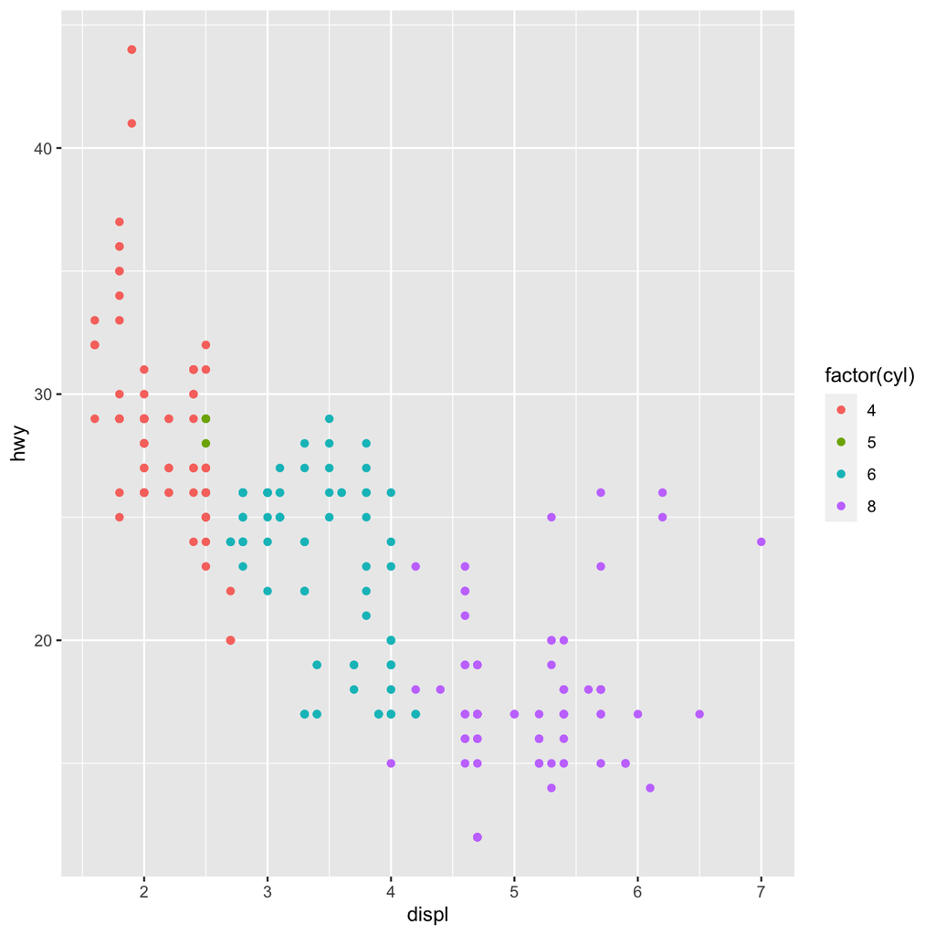

This is a MPG classic figure.

```r
mpg %>% ggplot(aes(displ, hwy, color = factor(cyl))) + geom_point()
```

```r
mpg
```

[output not shown]